# 2025 SWPO striped marlin BSPM – sc-pres

2025 Stock Assessment of Striped Marlin in the Southwest Pacific Ocean

*Part II: Data-moderate Bayesian Surplus Production Model Approach*

N. Ducharme-Barth, C. Castillo-Jordán, F. Carvalho, and P. Hamer

WCPFC-SC21 • Nuku’alofa, Tonga • 13–21 August 2025

## Openscience

All data inputs, model code, key model outputs, figures, report and presentation files are publicly available on GitHub:

https://n-ducharmebarth-noaa.github.io/2025-swpo-mls-bspm/

[figure not shown]

## Assessment context

- Strategic shift from integrated age-structured model to a Bayesian data-moderate approach
- Previous challenges with:
  - Data conflicts and poor fits to size composition
  - Challenges estimating population scale
- Bayesian Surplus Production Model (BSPM) offers simplified yet robust alternative when data limitations exist
- Complements integrated assessment (Part I) for holistic stock status view

## Why BSPM?

**Advantages:**

- Focuses on estimating productivity and scale given catch and index data
- Efficient exploration of parameter space
- Explicitly incorporates biological uncertainty through priors
- Proven robust and effective for pelagic fish assessments

**Trade-offs:**

- Simplifies complex age-structured dynamics
- Assumes single well-mixed population
- Knife-edged selectivity assumption

## Model framework

**Fletcher-Schaefer production model**

**Population dynamics:**
$$N_t = \left(N_{t-1} + \text{Production}_{t-1}\right) \times \text{Process error}_{t} \times \text{Fishing survival}_{t-1}$$

**Fishing impact linked to effort:**
$$\text{Fishing survival}_{t} \text{ inversely proportional to } \text{Fishing mortality}_t$$
$$\text{Fishing mortality}_{t} = \text{Catchability}_{t} \times \text{Fishing effort}_t$$

**Key features:**

- True population (numbers) is treated as an unobserved random variable
- Model only fits to observations of relative abundance and catch
- Catchability is allowed to vary temporally so fishing mortality can match catch
- Biology captured in `Production` as max rate of population growth $R_{Max}$

## Input data

**Catch data:**

- Aggregated annual removals in numbers of individuals

**Effort data:**

- Annual longline effort (hooks fished)

**Standardized CPUE indices:**

- DWFN longline index (1979-2022) & New Zealand recreational sportfish indices (1975-2022)
- Several observer-based indices explored as sensitivities

**Note**

Blue line is a moving average and not a model fit!

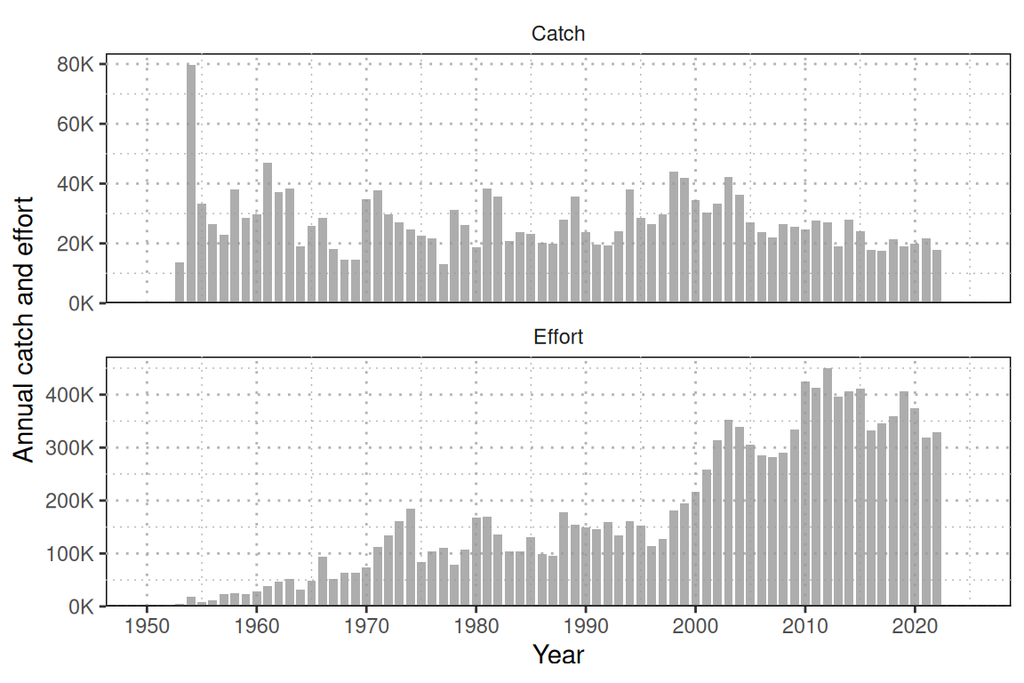

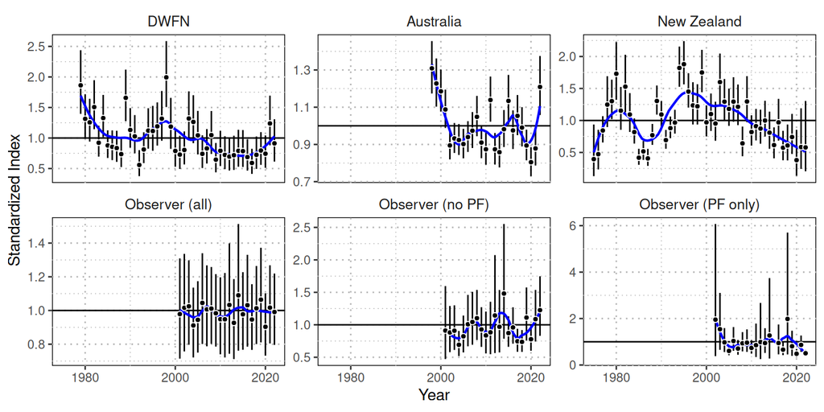

## Model development approach

**1. Develop priors:**

- Use biological simulation framework to develop initial prior for $R_{Max}$ and production function shape parameter $n$
- Develop priors for population scale and catchability based on maximum observed catch and early period CPUE

**2. Prior pushforward:**

- Pass random parameter combinations through the population dynamics model
- Filter parameter combinations for biological and fishery realism
- Develop a multivariate prior based on emergent parameter correlations

**3. Fit models to data 🤩**

- Evaluate model performance (fits & diagnostics)
- Draw inference from posterior updates
- Consider sensitivities to data inputs

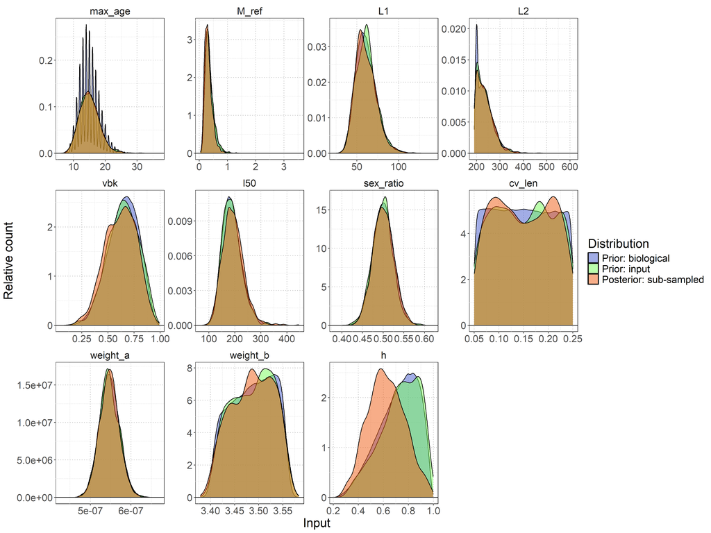

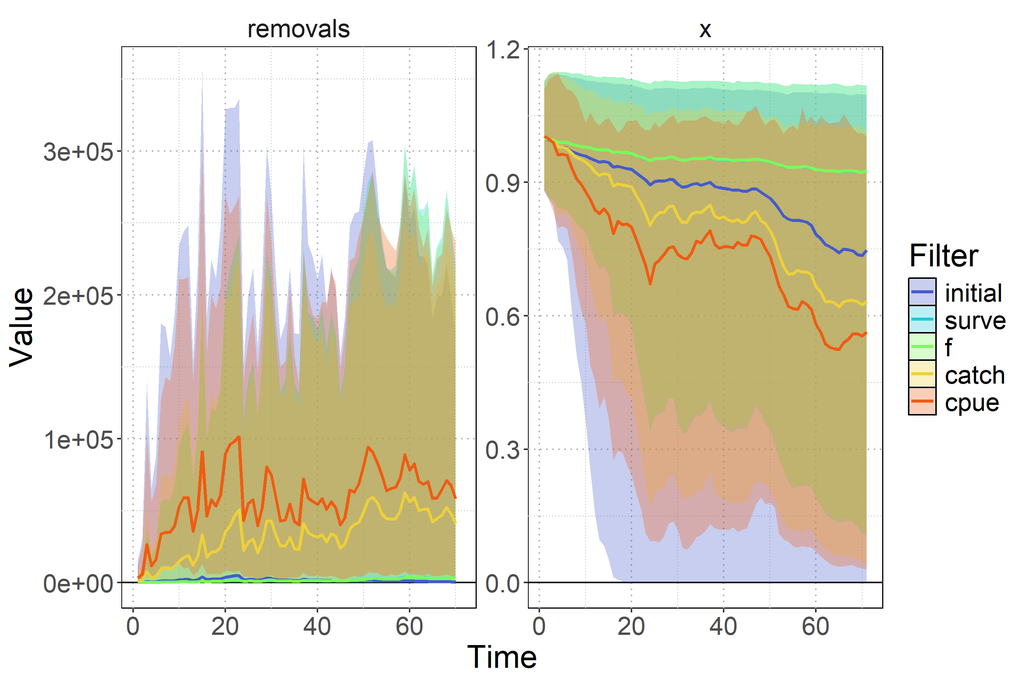

## Diagnostic model

- Fits to the DWFN index
- Uses a robust likelihood for fitting to catch data
- Estimates scale, $R_{Max}$, production shape, annual catchability deviates, process error, and index observation error
- Posterior distributions of estimated quantities were derived from sample chains starting from 5 different starting points
- Standard Bayesian diagnostics indicated that all sample chains satisfactorily converged to a stable distribution without issue

| Diagnostic | Value | Criteria | Status |
| --- | --- | --- | --- |
| Max $\hat{R}$ | 1.008 | < 1.01 | ✓ |
| Min ESS | 788.000 | > 500 | ✓ |
| Divergent | 0.000 | = 0 | ✓ |
| Tree Depth | 0.000 | = 0 | ✓ |

The diagnostic case model is model `0100`.

## Diagnostic model: Fits

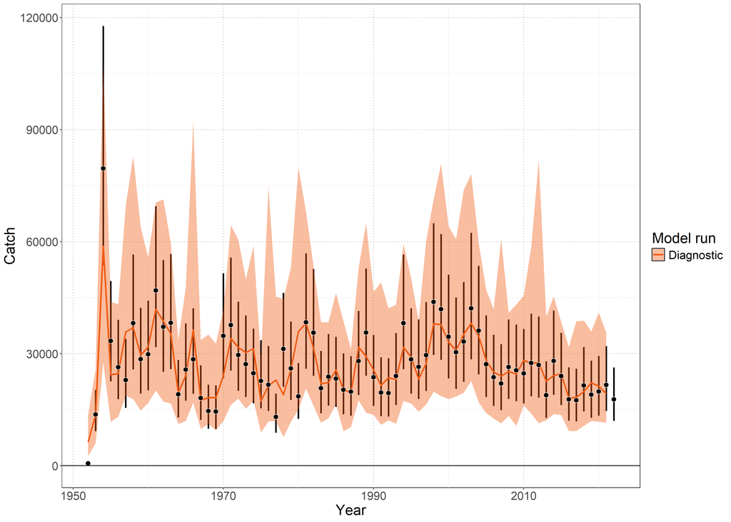

**Posterior-predictive distribution (**PPD**)**

• Distribution of expected values given estimation uncertainty & observation error

• Shaded polygon is the 95% interval

• Observations should fall within the **PPD**

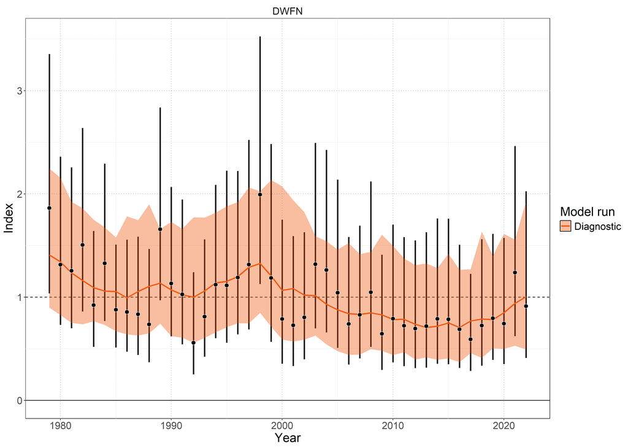

The diagnostic case model is model `0100`.

## Diagnostic model: Validation

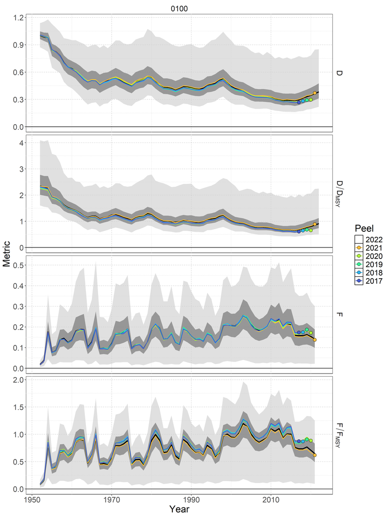

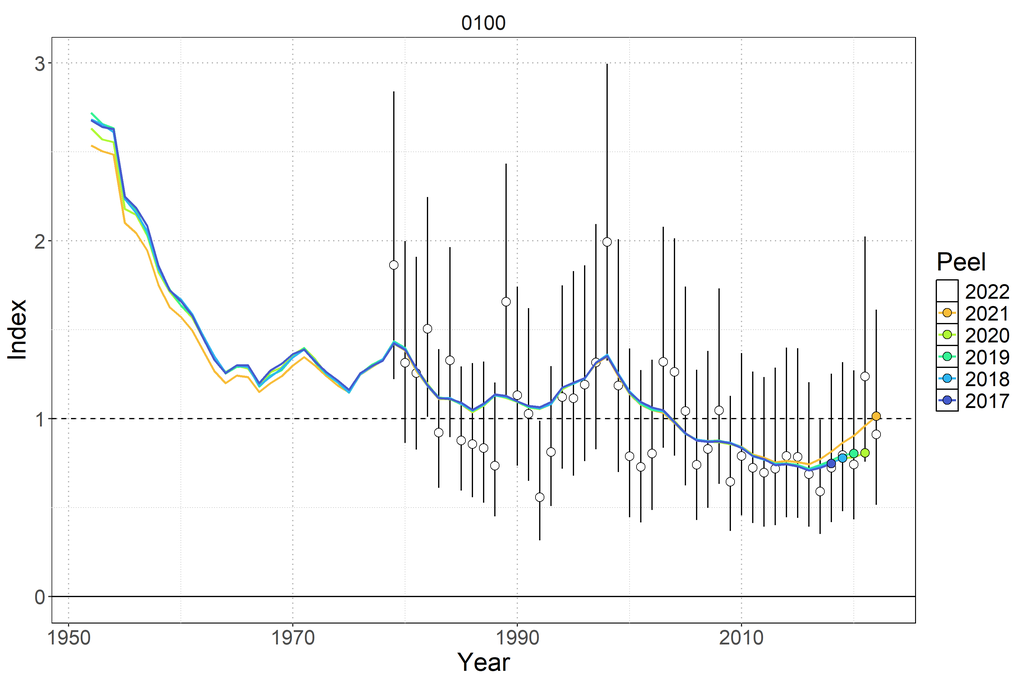

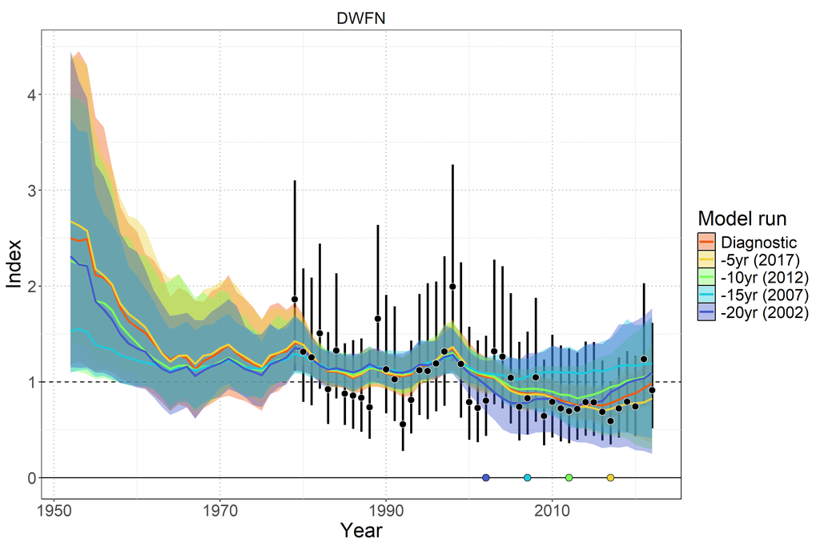

**Retrospectives**

• Models refit excluding terminal years of index

• Colors indicate terminal year of index data

• Refit models should remain close to *full* model

**Hindcast**

• Models refit excluding terminal years of index

• Colors indicate terminal year of index data

• Hindcast *future* index data based on model fit through last index year

• Predicted *future* index data should match observations

**Hindcast**

• Model predictions of the index holding out up to 20 years of data

• Good hindcast index fit indicates production and catch drive model estimates

The diagnostic case model is model `0100`.

## Diagnostic model: Inference

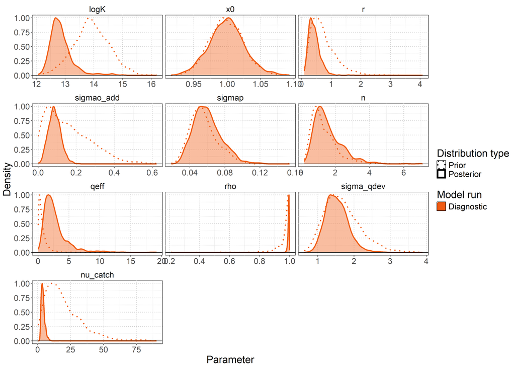

**Posterior update**

• If posterior (solid line) differs from realized prior (dotted line) distribution, data inform estimates

• Both key population dynamics parameters for scale (*logK*) and $R_{Max}$ (*r*) indicate strong influence of data on estimates

## Key sensitivities

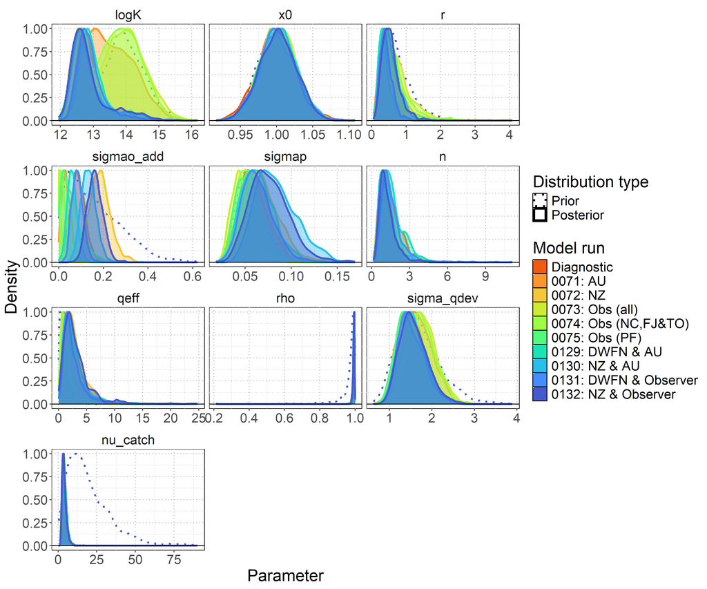

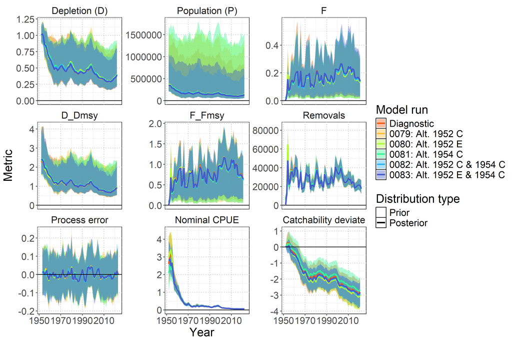

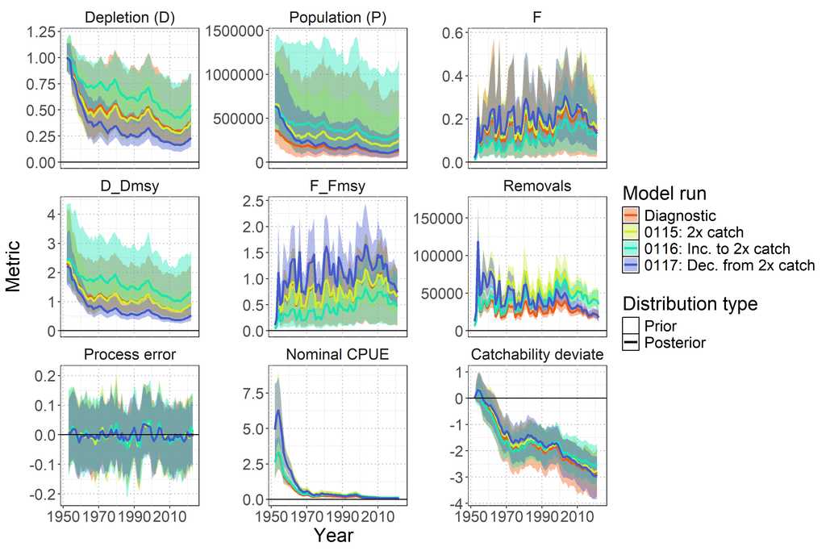

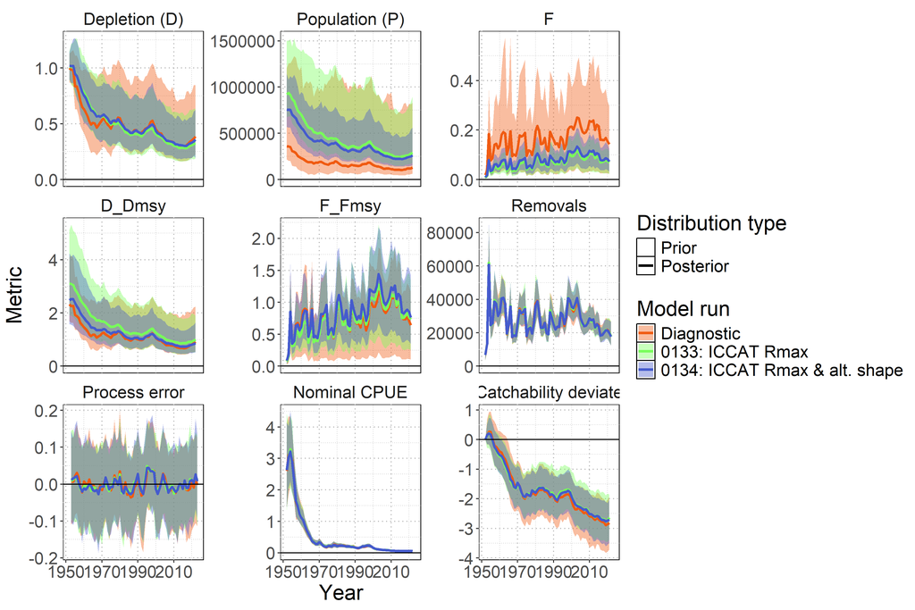

**Alternative indices**

• DWFN and New Zealand recreational indices are only indices with sufficient contrast to inform population scale

• Other indices show limited posterior updates from prior

**Early data**

• 1952 and 1954 catch observations identified as potentially problematic

• Model results robust to treatment of these early observations

**Catch reporting**

• Systematic under-reporting scenarios tested (constant and time-varying)

• Population scale and relative status sensitive to catch magnitude

**Alternative $R_{Max}$ prior**

• Lower productivity assumption based on Atlantic white marlin

• Results in larger population scale but similar relative stock status metrics

• Choice of shape *n* prior impacts scale estimate and *MSY* based reference points

Key sensitivities: indices (`0071`-`0075` & `0129`-`0132`), early data (`0079`-`0083`), catch reporting (`0115`-`0117`), and $R_{Max}$ prior (`0133`-`0134`).

## Model ensemble

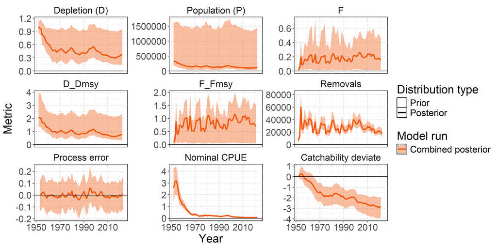

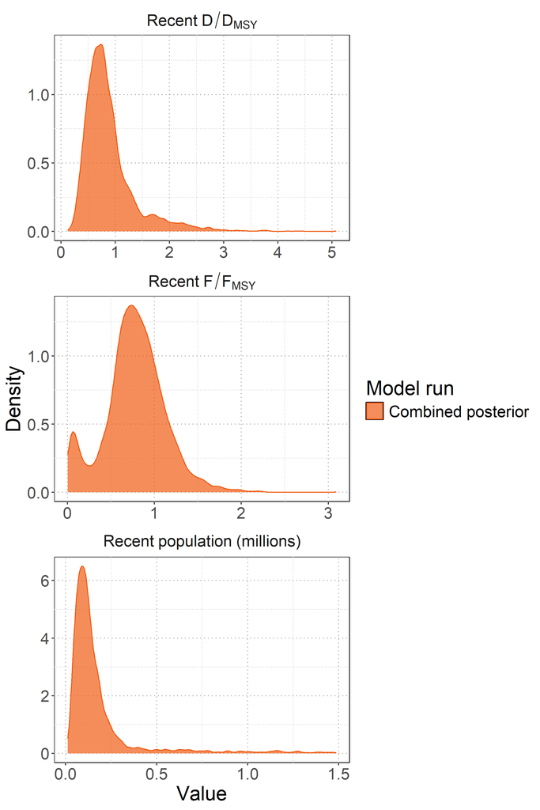

**Axes**

• Four model ensemble across two axes

• Two indices (DWFN & New Zealand recreational)

• Two shape parameter priors (life history based & conservative Schaefer)

**Trends**

• Fishing mortality: Increasing through 2000s, with more recent declines.

• Population scale: Large, asymmetric uncertainty

**Marginal posterior distributions**

• $D/D_{MSY}$: Majority of distribution (74%) below $D/D_{MSY}$

• $F/F_{MSY}$: Minority of distribution (23%) above $F/F_{MSY}$

• Population scale: Data supports a small recent population with large, asymmetric uncertainty to the high side

$D_{recent}$ refers to the average over 2019-2022

$F_{recent}$ refers to the average over 2018-2021

Solid line is posterior median, shading is 95% credible interval.

Depletion (D) is depletion in total numbers relative to initial total numbers.

Population (P) is total numbers of individuals.

Ensemble models: `0100`, `0102`, `0105`, `0107`.

## Stock status

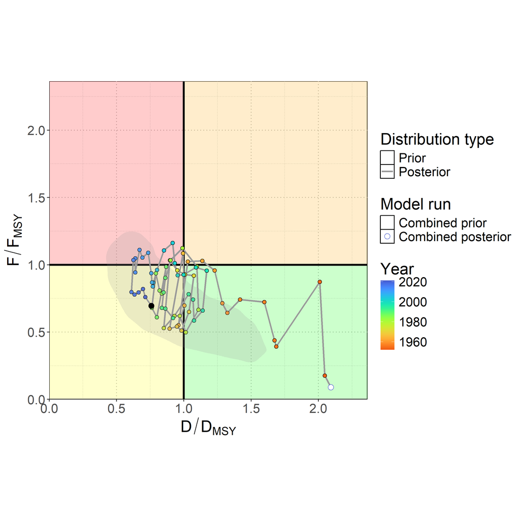

| **Metric** | **Median [95% CI]** | **Probability** |
| --- | --- | --- |
| **Recent Status** |  |  |
| $D_{recent}/D_{MSY}$ | 0.77 [0.33–2.3] | 74% below $D_{MSY}$ |
| $F_{recent}/F_{MSY}$ | 0.77 [0.05–1.51] | 22.9% above $F_{MSY}$ |
| **Latest Status** |  |  |
| $D_{latest}/D_{MSY}$ | 0.81 [0.32–2.36] | 70% below $D_{MSY}$ |
| $F_{latest}/F_{MSY}$ | 0.69 [0.05–1.51] | 18.4% above $F_{MSY}$ |

**Kobe plot**

• Time-trend of median stock status shown by line and points

• Uncertainty in latest estimates shown with gray polygon

$D_{recent}$ refers to the average over 2019-2022

$D_{latest}$ refers to 2022

$F_{recent}$ refers to the average over 2018-2021

$F_{latest}$ refers to 2021.

## Projections

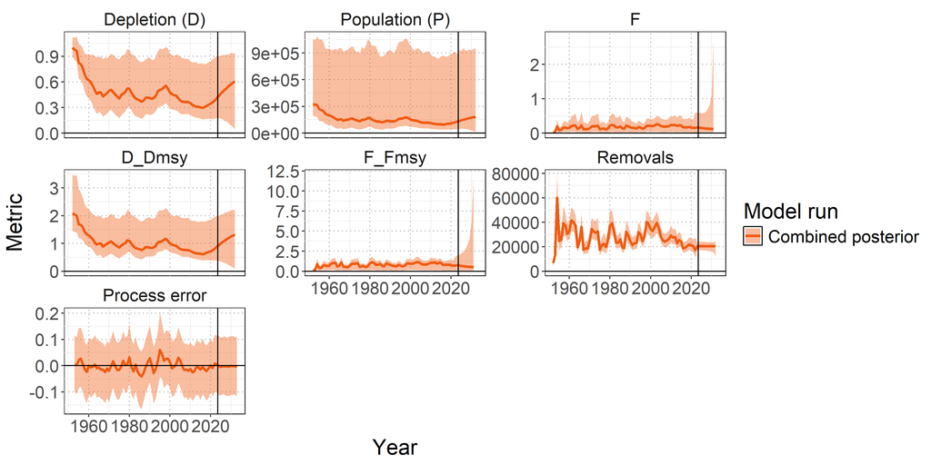

**Projection assumptions**

• Recent average catch (2018-2022)

• Stationary productivity & environment

• Process error resampled from model period

**Future overfished probabilities:**

• 2027: 40.9%

• 2032: 26%

## Limitations

**Data representativeness:**

- CPUE indices may not represent true stock trends
- Potential under-reporting of catches for bycatch stock
- Stock structure uncertainty (genetic evidence of SWPO fish in North Pacific catches)

**Model simplifications:**

- Single well-mixed population assumption
- Knife-edged selectivity
- No age structured dynamics
- Stationary productivity and carrying capacity over 70 years

**Parameter uncertainty:**

- Substantial uncertainty in absolute population scale
- Shape parameter $n$ not estimable from data
- High uncertainty in key biological processes translates to uncertainty in $R_{Max}$

**Environmental factors:**

- Future variability in environmental and oceanographic conditions are not explicitly modeled
- Process error spikes suggests unmodeled dynamics

## Recommendations

**Stock structure research:**

- Develop conceptual model for SWPO striped marlin
- Collaborate with ISC Billfish Working Group

**Data and biological research:**

- Reduce uncertainty in key biological processes where possible
- Investigate representativeness of abundance indices
- Address stock connectivity questions with genetic research

**Future modeling approach:**

- Progressive development within Bayesian framework
- Move toward Bayesian fully integrated age-structured models similar to WCPO oceanic whitetip shark

## Acknowledgements

Collaborative Assessment Process

This assessment greatly benefited from collaboration with a broad group of interested parties and stock assessment experts where feedback was provided in an iterative manner throughout the model development process. Leveraging their diverse expertise helped produce a stronger scientific product.

Special thanks to:

K. Kim (SPC), N. Davies (Te Takina Ltd.), S. Hoyle (Hoyle Consulting), R. Ahrens (PIFSC), and M. Nadon (PIFSC)

for their insights and thoughtful discussion which improved the assessment!